# BHao_HW3

# 3.1

```r
library(mlbench)
data(Glass)
str(Glass)
```

```
## 'data.frame':    214 obs. of  10 variables:
##  $ RI  : num  1.52 1.52 1.52 1.52 1.52 ...
##  $ Na  : num  13.6 13.9 13.5 13.2 13.3 ...
##  $ Mg  : num  4.49 3.6 3.55 3.69 3.62 3.61 3.6 3.61 3.58 3.6 ...
##  $ Al  : num  1.1 1.36 1.54 1.29 1.24 1.62 1.14 1.05 1.37 1.36 ...
##  $ Si  : num  71.8 72.7 73 72.6 73.1 ...
##  $ K   : num  0.06 0.48 0.39 0.57 0.55 0.64 0.58 0.57 0.56 0.57 ...
##  $ Ca  : num  8.75 7.83 7.78 8.22 8.07 8.07 8.17 8.24 8.3 8.4 ...
##  $ Ba  : num  0 0 0 0 0 0 0 0 0 0 ...
##  $ Fe  : num  0 0 0 0 0 0.26 0 0 0 0.11 ...
##  $ Type: Factor w/ 6 levels "1","2","3","5",..: 1 1 1 1 1 1 1 1 1 1 ...
```

## 3.1.a. Using visualizations, explore the predictor variables to understand their distributions as well as the relationships between predictors.

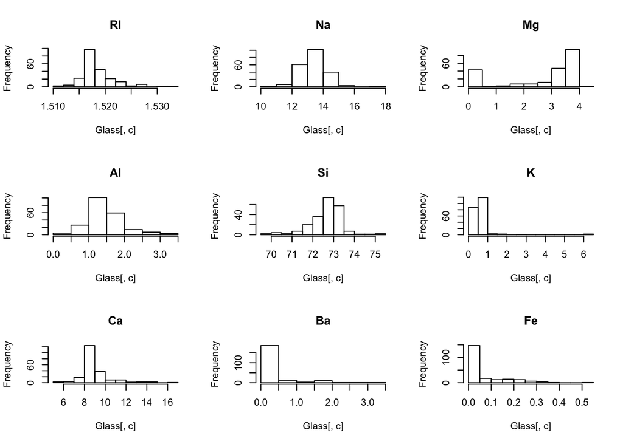

```r
preds = colnames(Glass)

# check histograms for each predictor
par(mfrow = c(3, 3))
for (c in 1:(length(preds)-1)){
  hist(Glass[, c], main = preds[c])
}
```

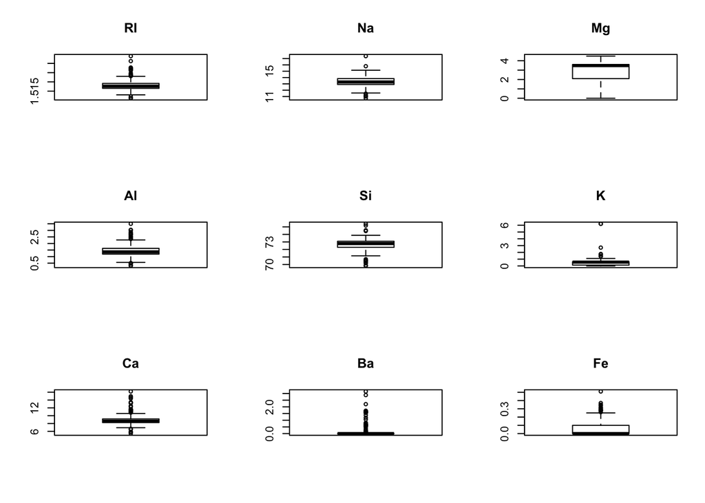

```r
# check boxplots for each predictor
par(mfrow = c(3, 3))
for (c in 1:(length(preds)-1)){
  boxplot(Glass[, c], main = preds[c])
}
```

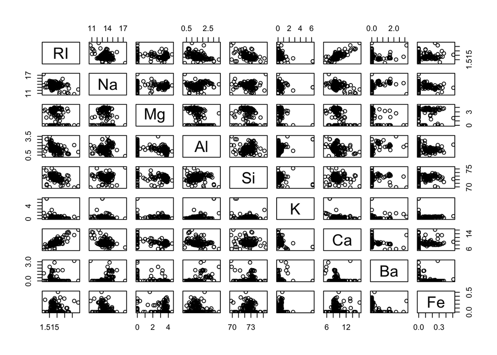

```r
# check scatter plot matrix
pairs(Glass[, 1:9])
```

## 3.1.b. Do their appear to be any outliers in the data? Are any predictors skewed?

Based on the histograms and boxplots, the following predictors appear to contain outliers: RI, Na, Al, Si, K, Ca, Ba, Fe. However, K, Ba, Fe are highly skewed to the right, so it’s harder to see if the observations in the tails are in fact outliers.

## 3.1.c. Are there any relevant transformations of one or more predictors that might improve the classification model?

Center and scale - since the predictors have significantly different scales, depending on the classification model, centering and scaling may improve classification results.

Log transformation - since predictors K, Ba and Fe are highly skewed, we can consider using a log transformation.

# 3.2

```r
data("Soybean")
str(Soybean)
```

```
## 'data.frame':    683 obs. of  36 variables:
##  $ Class          : Factor w/ 19 levels "2-4-d-injury",..: 11 11 11 11 11 11 11 11 11 11 ...
##  $ date           : Factor w/ 7 levels "0","1","2","3",..: 7 5 4 4 7 6 6 5 7 5 ...
##  $ plant.stand    : Ord.factor w/ 2 levels "0"<"1": 1 1 1 1 1 1 1 1 1 1 ...
##  $ precip         : Ord.factor w/ 3 levels "0"<"1"<"2": 3 3 3 3 3 3 3 3 3 3 ...
##  $ temp           : Ord.factor w/ 3 levels "0"<"1"<"2": 2 2 2 2 2 2 2 2 2 2 ...
##  $ hail           : Factor w/ 2 levels "0","1": 1 1 1 1 1 1 1 2 1 1 ...
##  $ crop.hist      : Factor w/ 4 levels "0","1","2","3": 2 3 2 2 3 4 3 2 4 3 ...
##  $ area.dam       : Factor w/ 4 levels "0","1","2","3": 2 1 1 1 1 1 1 1 1 1 ...
##  $ sever          : Factor w/ 3 levels "0","1","2": 2 3 3 3 2 2 2 2 2 3 ...
##  $ seed.tmt       : Factor w/ 3 levels "0","1","2": 1 2 2 1 1 1 2 1 2 1 ...
##  $ germ           : Ord.factor w/ 3 levels "0"<"1"<"2": 1 2 3 2 3 2 1 3 2 3 ...
##  $ plant.growth   : Factor w/ 2 levels "0","1": 2 2 2 2 2 2 2 2 2 2 ...
##  $ leaves         : Factor w/ 2 levels "0","1": 2 2 2 2 2 2 2 2 2 2 ...
##  $ leaf.halo      : Factor w/ 3 levels "0","1","2": 1 1 1 1 1 1 1 1 1 1 ...
```

[output cut: 22 more lines]

## 3.2.a. Investigate the frequency distributions for the categorical predictors. Are any of the distributions degenerate in the ways discussed earlier in this chapter?

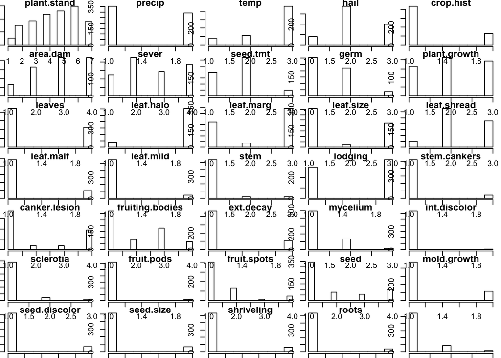

```r
preds = colnames(Soybean[, 2:length(colnames(Soybean))])

# check historgrams for each predictor
par(mfrow = c(7, 5), mar = c(.5, .5, .5, .5))
for (c in 2:length(colnames(Soybean))){
  hist(as.numeric(Soybean[, c]),
       main = preds[c])  # need to change margins to prevent error
}
```

```r
# calculate fraction of unique values and ratio of frequency between 1st and 2nd most prevalent value
df = data.frame(pred = as.character(),
                deg  = as.character())
for (c in 2:length(colnames((Soybean)))){
  uniq_frac = (length(unique(Soybean[, c])) / length(Soybean[, c])) < 0.1

  # determine frequency of top 1 and 2 values
  var1_freq = sort(table(Soybean[, c]), decreasing = TRUE, useNA = 'ifany')[1]
  var2_freq = sort(table(Soybean[, c]), decreasing = TRUE, useNA = 'ifany')[2]
  freq_ratio= (var1_freq / var2_freq) > 20
  uniq_frac & freq_ratio
  df_temp   = data.frame(preds[c], uniq_frac & freq_ratio)
  df        = rbind(df, df_temp)
}
colnames(df)= c('pred', 'deg')

# return only those predictors that meet degenerate rules
df[df['deg'] == TRUE, ]
```

[output not shown]

## 3.2.b. Roughly 18% of the data are missing. Are there particular predictors that are more likely to be missing? Is the pattern of missing data related to the classes?

Yes, the table below shows the predictors by number of NAs, top to bottom.

The second table below shows the number of complete rows (i.e. no NAs) by Class. As shown, only phytophthora-rot has complete and incomplete records. All other classes have records that are all complete or are all missing values.

```r
library(dplyr)
library(tidyr)

summary(Soybean)
```

```
##                  Class          date     plant.stand  precip      temp
##  brown-spot         : 92   5      :149   0   :354    0   : 74   0   : 80
##  alternarialeaf-spot: 91   4      :131   1   :293    1   :112   1   :374
##  frog-eye-leaf-spot : 91   3      :118   NA's: 36    2   :459   2   :199
##  phytophthora-rot   : 88   2      : 93               NA's: 38   NA's: 30
##  anthracnose        : 44   6      : 90
##  brown-stem-rot     : 44   (Other):101
##  (Other)            :233   NA's   :  1
##    hail     crop.hist  area.dam    sever     seed.tmt     germ
##  0   :435   0   : 65   0   :123   0   :195   0   :305   0   :165
##  1   :127   1   :165   1   :227   1   :322   1   :222   1   :213
##  NA's:121   2   :219   2   :145   2   : 45   2   : 35   2   :193
##             3   :218   3   :187   NA's:121   NA's:121   NA's:112
##             NA's: 16   NA's:  1
##
##
##  plant.growth leaves  leaf.halo  leaf.marg  leaf.size  leaf.shread
##  0   :441     0: 77   0   :221   0   :357   0   : 51   0   :487
##  1   :226     1:606   1   : 36   1   : 21   1   :327   1   : 96
##  NA's: 16             2   :342   2   :221   2   :221   NA's:100
##                       NA's: 84   NA's: 84   NA's: 84
##
##
##
##  leaf.malf  leaf.mild    stem     lodging    stem.cankers canker.lesion
##  0   :554   0   :535   0   :296   0   :520   0   :379     0   :320
##  1   : 45   1   : 20   1   :371   1   : 42   1   : 39     1   : 83
##  NA's: 84   2   : 20   NA's: 16   NA's:121   2   : 36     2   :177
##             NA's:108                         3   :191     3   : 65
##                                              NA's: 38     NA's: 38
##
##
##  fruiting.bodies ext.decay  mycelium   int.discolor sclerotia  fruit.pods
##  0   :473        0   :497   0   :639   0   :581     0   :625   0   :407
##  1   :104        1   :135   1   :  6   1   : 44     1   : 20   1   :130
##  NA's:106        2   : 13   NA's: 38   2   : 20     NA's: 38   2   : 14
##                  NA's: 38              NA's: 38                3   : 48
##                                                                NA's: 84
##
##
##  fruit.spots   seed     mold.growth seed.discolor seed.size  shriveling
##  0   :345    0   :476   0   :524    0   :513      0   :532   0   :539
##  1   : 75    1   :115   1   : 67    1   : 64      1   : 59   1   : 38
##  2   : 57    NA's: 92   NA's: 92    NA's:106      NA's: 92   NA's:106
##  4   :100
##  NA's:106
##
##
##   roots
##  0   :551
##  1   : 86
##  2   : 15
##  NA's: 31
##
##
##
```

```r
Soybean %>% select(-one_of(c('Class'))) %>%
  summarise_each(funs(sum(is.na(.)))) %>%
  gather(pred, n_na) %>%
  arrange(desc(n_na))
```

```
##               pred n_na
## 1             hail  121
## 2            sever  121
## 3         seed.tmt  121
## 4          lodging  121
## 5             germ  112
## 6        leaf.mild  108
## 7  fruiting.bodies  106
## 8      fruit.spots  106
## 9    seed.discolor  106
## 10      shriveling  106
## 11     leaf.shread  100
## 12            seed   92
## 13     mold.growth   92
## 14       seed.size   92
```

[output cut: 21 more lines]

```r
any_na = Soybean %>% complete.cases()
Soybean %>% mutate(any_na = any_na) %>%
  group_by(Class, any_na) %>%
  summarise(n = n()) %>%
  spread(any_na, n) %>%
  arrange(`TRUE`, `FALSE`, Class) %>%
  rename('has_NAs' = `FALSE`, 'no_NAs' = `TRUE`)
```

```
## Source: local data frame [19 x 3]
## Groups: Class [19]
##
##                          Class has_NAs no_NAs
##                         <fctr>   <int>  <int>
## 1             phytophthora-rot      68     20
## 2             bacterial-blight      NA     20
## 3            bacterial-pustule      NA     20
## 4                 charcoal-rot      NA     20
## 5        diaporthe-stem-canker      NA     20
## 6                 downy-mildew      NA     20
## 7       phyllosticta-leaf-spot      NA     20
## 8               powdery-mildew      NA     20
## 9            purple-seed-stain      NA     20
## 10        rhizoctonia-root-rot      NA     20
## 11                 anthracnose      NA     44
## 12              brown-stem-rot      NA     44
## 13         alternarialeaf-spot      NA     91
## 14          frog-eye-leaf-spot      NA     91
## 15                  brown-spot      NA     92
## 16            herbicide-injury       8     NA
## 17               cyst-nematode      14     NA
## 18 diaporthe-pod-&-stem-blight      15     NA
## 19                2-4-d-injury      16     NA
```

## 3.2.c. Develop a strategy for handling missing data, either by eliminating predictors or imputation.